# Visualizing the ‘How Couples Meet and Stay Together’ Survey by Rosenfeld et al, 2018

Peter Silverstein

2025-06-04

This assignment for the QMSS Data Visualization course at Columbia was focused on understanding patterns in the How Couples Meet and Stay Together (HCMST) survey from Stanford University. The primary goal was to apply fundamental principles of data visualization to a real dataset. I focused on creating visually-appealing, simple, and narrative-driven graphics.

## Dating Trends Over Time

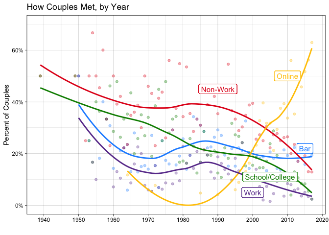

We can clearly see the sharp upward trend in couples meeting online from the early 90s onward (it should be noted that I did not do any data cleaning on this dataset, so there are some slightly suspect data points, such as the couple in 1964 that indicated they met online). All other modes (with the possible exception of Bar) have declined over time, especially school/college and non-work.

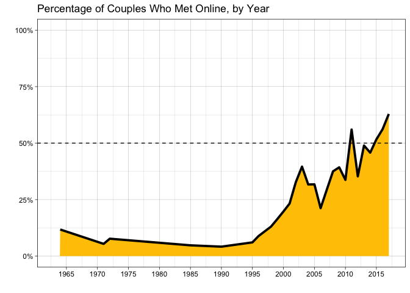

### Alternative: Combining the Two Charts

I like both charts on their own, but what if we combine them?

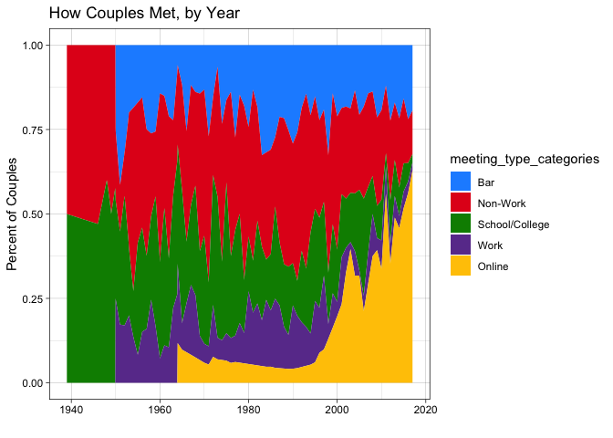

Though I enjoy looking at the alternative chart that I made, and it does combine the comparison across categories (chart 1) with the visualization of online meeting crossing the 50% threshold, I think it would be better to rely on the 2 charts rather than this single one. First, it is quite hard to discern the difference between the categories by year in this alternative–humans are not great at these sorts of vertical comparisons. Second, and relatedly, the trends of the individual meeting type categories are not very discernible, since they largely depend on the values of the other categories. The exceptions to this are the bar and online categories, which have the upper and lower bounds of the graph as their reference points. Finally, while it does present the same information as the second chart (the point at which online meetings cross 50%), it does so in a much more visually cluttered way. It would be better to present the first chart, which is a better way of comparing trends over time, and then the second chart, which does a better job of highlighting the specific trend in online meetings.

## Age is Just a Number

The following chart visualizes the relationship between age of the individual and the age of their partner. Men are generally more likely to have younger partners, and it seems as though the gap gets bigger as age increases, although this may not be outside the margin of error.

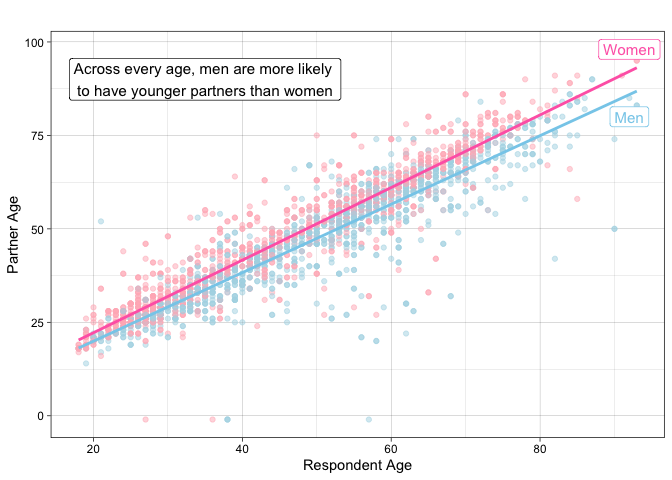

In the assignment, we were asked to reflect on the visualization and think about what Edward Tufte might say about it. I think the first thing that Tufte would say is that I could make this chart more simple. Though it is fairly simple now, removing the scatterplot points and the grid lines would keep the main story while reducing visual clutter (to be clear, I disagree with this–the points add valuable information in my view and the grid lines help with comparisons). I also wonder if Tufte would critique the dimensions of this plot. Although the integrity of the data isn’t compromised by my visualization, I do think that the rectangular nature of the plot does make the relationship seem shallower than it really is.

## Politics and Dating

How is political affiliation related to dating and the social aspect of sexuality?

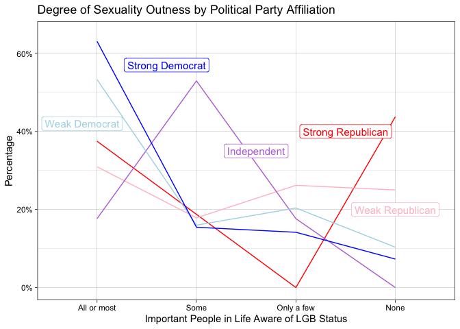

It’s pretty clear that Strong Democrats from the LGB community are more likely to be out than their Strong Republican counterparts. Interestingly, Independents are far more likely to have “some” people aware of their sexuality, which indicates that this group likely has a diverse social circle and is often careful about what information they share with whom.

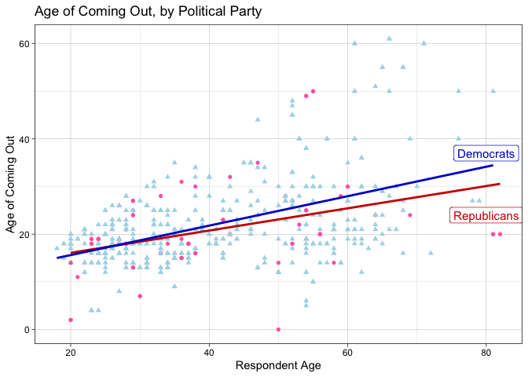

In the second plot, we can see respondent age plotted against the age at which they came out. Although most respondents came out before they turned 40, many older Democrats came out in older age. Though the trend lines are somewhat similar, they do indicate that Democrats were more likely to be slightly older when they came out and that this difference is more pronounced among older respondents.

## Pay Equality and US Regions

I was interested in how US Regions differed in whether couples had similar pay levels.

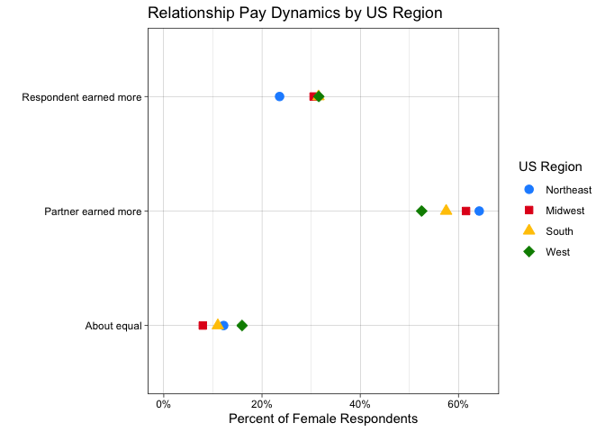

This chart tells a simple story: we can see how US regions stack up against each other when it comes to whether women make more than their partners. The West region leads all regions in percentage of women who (a) earned more in 2016 than their partners or (b) earned about equal. The regions are generally within about 10 percentage points of each other, but that’s a big swing. The Northeast is the region in which the most women make less than their partners. I chose this visualization because it allows for simple and direct comparisons across regions–the dot plot is a good alternative to the bar chart for comparison. The markers are both colored and shaped separately for each region, which allows for easy distinguishing between points.

## Interactivity

For the final part of the assignment, we were told to take some of the previous visualizations and make them interactive. I did the first one using `ggplotly` (a simple and automatic solution) and did the second one more manually.

[interactive chart not shown]

This chart is a worthwhile one to make interactive simply because it allows the user to zoom into a particular time frame, cut out extra noise, and see a pattern for the particular date range they’re interested in. Additionally, it may be interesting to see the specific values for each year.

[interactive chart not shown]

The primary reason I like that this chart is interactive is that it allows a quick and accurate comparison of exact percentages. Especially when the dots are really close to each other, this can help the reader differentiate between points. Additionally, for the “Respondent earned more” category, it is the case that two points overlap. By having the option to zoom in, the reader may dive into the exact difference between these points.

### Interactive Data Table of Respondent Political Party, Partner Political Party, and Relationship Satisfaction

|  | Respondent ID | Respondent Political Party | Partner Political Party | Relationship Satisfaction |
| --- | --- | --- | --- | --- |
| 1 | 11 | Strong Democrat | Leans Democrat | Excellent |
| 2 | 37 | Leans Republican | Undecided/Independent/Other | Fair |
| 3 | 38 | Not Strong Republican | Undecided/Independent/Other | Excellent |
| 4 | 78 | Leans Republican | Leans Republican | Good |
| 5 | 83 | Leans Democrat | Leans Democrat | Excellent |
| 6 | 88 | Strong Republican | Leans Republican | Excellent |
| 7 | 142 | Strong Republican | Strong Republican | Excellent |
| 8 | 180 | Leans Republican | Leans Republican | Excellent |
| 9 | 187 | Strong Democrat | Leans Democrat | Good |
| 10 | 202 | Not Strong Democrat | Undecided/Independent/Other | Excellent |

[output cut: 2872 more lines]